# PCA & Clustering – ACP_eaux

MAIRAME SAMBA NIANG

March 29, 2026

## Data Reading

```r
# Load dataset
eaux <- read.table("ACP_eaux.txt", header = TRUE, sep = "\t",
                   dec = ",", fileEncoding = "latin1")

# Fix duplicate acronym: VERN appears twice (Vernière & Vernet)
eaux$ACRO[eaux$NOM == "Vernet"] <- "VERNET"
row.names(eaux) <- eaux$ACRO
X <- eaux[, c("CA", "MG", "NA.", "K", "SUL", "NO3", "HCO3", "CL")]
colnames(X) <- c("Ca", "Mg", "Na", "K", "Sul", "No3", "HCO3", "Cl")
head(X, 4)
```

|  | Ca | Mg | Na | K | Sul | No3 | HCO3 | Cl |
| --- | --- | --- | --- | --- | --- | --- | --- | --- |
| EVIAN | 78 | 24.0 | 5.0 | 1.0 | 10 | 3.8 | 357 | 4.5 |
| MTPYR | 48 | 11.0 | 34.0 | 1.0 | 16 | 4.0 | 183 | 50.0 |
| CRIST | 71 | 5.5 | 11.2 | 3.2 | 5 | 1.0 | 250 | 20.0 |
| FIEE | 89 | 31.0 | 17.0 | 2.0 | 47 | 0.0 | 360 | 28.0 |

```r
colMeans(X)
```

```
##         Ca         Mg         Na          K        Sul        No3       HCO3
## 102.458246  25.861930  93.851754  11.090351 135.661404   3.834211 442.166842
##         Cl
##  52.473684
```

```r
# Covariance matrix
cov(X)
```

```
##               Ca          Mg          Na           K         Sul        No3
## Ca   14393.56109  2385.77511   2791.0709   367.48743  36063.8241  -50.76371
## Mg    2385.77511   800.79836   3391.3854   457.15903   5640.5337  -40.08464
## Na    2791.07093  3391.38544  38908.0968  4032.14877   4175.1775 -152.91948
## K      367.48743   457.15903   4032.1488   597.08281   -202.3603  -27.04109
## Sul  36063.82407  5640.53367   4175.1775  -202.36029 108378.0953 -343.62267
## No3    -50.76371   -40.08464   -152.9195   -27.04109   -343.6227   44.48082
## HCO3  9848.56100 10668.69980 102735.3237 13103.60707 -13845.0934 -245.00363
## Cl    4750.41110  1950.90568  16601.1150  1401.67912  14988.0411 -114.80944
##             HCO3         Cl
## Ca     9848.5610  4750.4111
## Mg    10668.6998  1950.9057
## Na   102735.3237 16601.1150
## K     13103.6071  1401.6791
## Sul  -13845.0934 14988.0411
## No3    -245.0036  -114.8094
## HCO3 370028.7077 16610.6510
## Cl    16610.6510 20520.5023
```

```r
# Correlation matrix
cor(X)
```

```
##               Ca         Mg          Na           K         Sul         No3
## Ca    1.00000000  0.7027224  0.11794153  0.12535483  0.91309695 -0.06344287
## Mg    0.70272239  1.0000000  0.60756895  0.66113238  0.60546334 -0.21238801
## Na    0.11794153  0.6075689  1.00000000  0.83656419  0.06429603 -0.11624022
## K     0.12535483  0.6611324  0.83656419  1.00000000 -0.02515575 -0.16592834
## Sul   0.91309695  0.6054633  0.06429603 -0.02515575  1.00000000 -0.15650372
## No3  -0.06344287 -0.2123880 -0.11624022 -0.16592834 -0.15650372  1.00000000
## HCO3  0.13494940  0.6197724  0.85621354  0.88156811 -0.06913651 -0.06039047
## Cl    0.27640957  0.4812610  0.58752083  0.40043988  0.31781920 -0.12017032
##             HCO3         Cl
## Ca    0.13494940  0.2764096
## Mg    0.61977235  0.4812610
## Na    0.85621354  0.5875208
## K     0.88156811  0.4004399
## Sul  -0.06913651  0.3178192
## No3  -0.06039047 -0.1201703
## HCO3  1.00000000  0.1906228
## Cl    0.19062285  1.0000000
```

**Interpretation:** The data shows 57 mineral waters with 8 variables (mg/L). Variables have very different scales (HCO3 mean ≈ 442 vs No3 ≈ 3.8 mg/L), so a **scaled PCA** is required. Strong correlations: Ca–Sul (r = +0.91), Na–HCO3 (r = +0.86), Na–K (r = +0.84). No3 is almost uncorrelated with all others (|r| ≤ 0.21) — it is an independent variable of anthropogenic origin.

## Correlation Matrix Plot

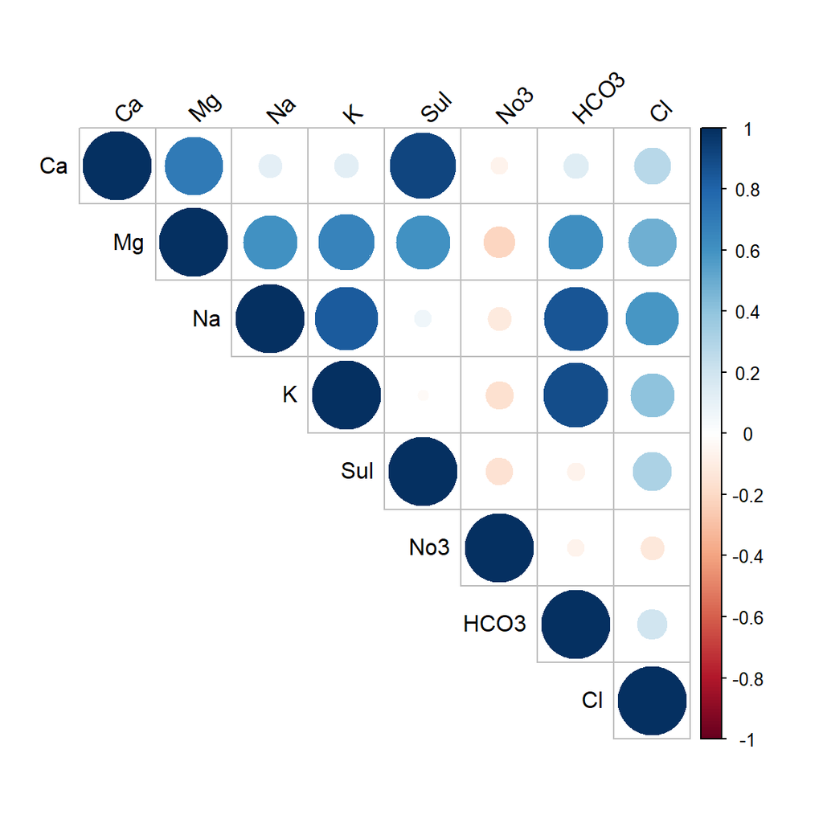

```r
library(corrplot)
matcor <- cor(X)
corrplot(matcor, type = "upper", tl.col = "black", tl.srt = 45)
```

## PCA Function

```r
library(FactoMineR)
library(factoextra)
```

```r
# Unscaled PCA
# res.pca <- PCA(X, graph = FALSE, scale.unit = FALSE)

# Scaled PCA (recommended: variables have very different variances)
res.pca <- PCA(X, graph = FALSE)
print(res.pca)
```

```
## **Results for the Principal Component Analysis (PCA)**
## The analysis was performed on 57 individuals, described by 8 variables
## *The results are available in the following objects:
##
##    name               description
## 1  "$eig"             "eigenvalues"
## 2  "$var"             "results for the variables"
## 3  "$var$coord"       "coord. for the variables"
## 4  "$var$cor"         "correlations variables - dimensions"
## 5  "$var$cos2"        "cos2 for the variables"
## 6  "$var$contrib"     "contributions of the variables"
## 7  "$ind"             "results for the individuals"
## 8  "$ind$coord"       "coord. for the individuals"
## 9  "$ind$cos2"        "cos2 for the individuals"
## 10 "$ind$contrib"     "contributions of the individuals"
## 11 "$call"            "summary statistics"
## 12 "$call$centre"     "mean of the variables"
## 13 "$call$ecart.type" "standard error of the variables"
## 14 "$call$row.w"      "weights for the individuals"
## 15 "$call$col.w"      "weights for the variables"
```

##Interpretation: The scaled PCA (`scale.unit = TRUE`) standardises all variables to unit variance before decomposition, ensuring each ion contributes equally to the analysis regardless of its measurement scale. The output confirms that 8 principal components are extracted (one per variable), and provides access to eigenvalues, variable coordinates, and individual scores.

## Eigenvalues

```r
res.pca$eig
```

```
##          eigenvalue percentage of variance cumulative percentage of variance
## comp 1 3.8167747447           47.709684309                          47.70968
## comp 2 2.0680904354           25.851130442                          73.56081
## comp 3 0.9728158313           12.160197892                          85.72101
## comp 4 0.7962420036            9.953025045                          95.67404
## comp 5 0.1792036107            2.240045134                          97.91408
## comp 6 0.0924269941            1.155337427                          99.06942
## comp 7 0.0740850743            0.926063429                          99.99548
## comp 8 0.0003613058            0.004516322                         100.00000
```

```r
eig.val = res.pca$eig
eig.val
```

```
##          eigenvalue percentage of variance cumulative percentage of variance
## comp 1 3.8167747447           47.709684309                          47.70968
## comp 2 2.0680904354           25.851130442                          73.56081
## comp 3 0.9728158313           12.160197892                          85.72101
## comp 4 0.7962420036            9.953025045                          95.67404
## comp 5 0.1792036107            2.240045134                          97.91408
## comp 6 0.0924269941            1.155337427                          99.06942
## comp 7 0.0740850743            0.926063429                          99.99548
## comp 8 0.0003613058            0.004516322                         100.00000
```

```r
# or
eig.val <- get_eigenvalue(res.pca)
eig.val
```

```
##         eigenvalue variance.percent cumulative.variance.percent
## Dim.1 3.8167747447     47.709684309                    47.70968
## Dim.2 2.0680904354     25.851130442                    73.56081
## Dim.3 0.9728158313     12.160197892                    85.72101
## Dim.4 0.7962420036      9.953025045                    95.67404
## Dim.5 0.1792036107      2.240045134                    97.91408
## Dim.6 0.0924269941      1.155337427                    99.06942
## Dim.7 0.0740850743      0.926063429                    99.99548
## Dim.8 0.0003613058      0.004516322                   100.00000
```

##Interpretation: The eigenvalue table shows how much variance each principal component captures:

- *PC1* (λ = 3.817) explains *47.7%* of total variance,the dominant axis.
- *PC2* (λ = 2.068) explains *25.9%* ,together PC1 + PC2 explain *73.6%* of variance.
- *PC3* (λ = 0.973) explains *12.2%* , brings the cumulative total to *85.7%*.
- *PC4* (λ = 0.796) explains an additional 9.95% (cumulative: 95.7%).
- PC5 to PC8 together explain only 4.3% and are discarded.

Applying *Kaiser’s criterion* (retain components with λ > 1): PC1 and PC2 are clearly retained. PC3 (λ = 0.973, very close to 1) may also be considered, particularly since it captures the nitrate dimension. The *factorial plane PC1 × PC2* is sufficient for a robust exploratory analysis.

## Results for Variables

```r
var <- get_pca_var(res.pca)
var
```

```
## Principal Component Analysis Results for variables
##  ===================================================
##   Name       Description
## 1 "$coord"   "Coordinates for the variables"
## 2 "$cor"     "Correlations between variables and dimensions"
## 3 "$cos2"    "Cos2 for the variables"
## 4 "$contrib" "contributions of the variables"
```

#Interpretation: The `var` object contains four key elements for each variable: `$coord` (coordinates/loadings), `$cor` (correlations with components), `$cos2` (quality of representation), and `$contrib` (percentage contributions to each component).

## Correlations between variables and components

```r
head(var$cor)
```

```
##          Dim.1      Dim.2        Dim.3       Dim.4        Dim.5
## Ca   0.5496004  0.7764150  0.170495237 -0.17809784  0.005109279
## Mg   0.9104573  0.2544056  0.036883459 -0.14815849 -0.196246861
## Na   0.8551621 -0.4142770  0.033126250  0.15439228  0.262944434
## K    0.8354674 -0.4584741 -0.005010044 -0.10636587 -0.190470398
## Sul  0.4496677  0.8675799  0.031460991 -0.02949458  0.141085221
## No3 -0.2337948 -0.0900040  0.958423890  0.13060377 -0.026621009
```

**Interpretation:** The correlation coefficients between variables and principal components reveal the structure of each axis:

- **PC1** is strongly and positively correlated with Mg (+0.91), Na (+0.86), K (+0.84), HCO3 (+0.78), Cl (+0.62), and Ca (+0.55). All ionic variables (except No3) contribute positively. **PC1 therefore represents the overall level of mineralisation**: waters with high PC1 scores are highly mineralised; those with low scores are very low in minerals.
- **PC2** opposes Ca (+0.78) and Sul (+0.87) (positive side) against Na (−0.41), K (−0.46), and HCO3 (−0.50) (negative side). **PC2 distinguishes the geochemical type**: sulphated-calcic waters (gypsum dissolution) on the positive side versus sodic-bicarbonated waters (volcanic/thermal springs) on the negative side.
- **PC3** is almost exclusively defined by No3 (+0.958), confirming that nitrates form an independent dimension linked to surface contamination rather than geological mineralisation.

## Coordinates of variables

```r
head(var$coord)
```

```
##          Dim.1      Dim.2        Dim.3       Dim.4        Dim.5
## Ca   0.5496004  0.7764150  0.170495237 -0.17809784  0.005109279
## Mg   0.9104573  0.2544056  0.036883459 -0.14815849 -0.196246861
## Na   0.8551621 -0.4142770  0.033126250  0.15439228  0.262944434
## K    0.8354674 -0.4584741 -0.005010044 -0.10636587 -0.190470398
## Sul  0.4496677  0.8675799  0.031460991 -0.02949458  0.141085221
## No3 -0.2337948 -0.0900040  0.958423890  0.13060377 -0.026621009
```

**Interpretation:** The coordinates of variables in the principal component space are equivalent to their correlations with the components (in a scaled PCA). They are used to position variables on the correlation circle. Variables with coordinates close to ±1 on a given axis are strongly associated with that axis. For example, Mg has a coordinate of +0.91 on PC1, placing it very close to the edge of the circle along the PC1 axis, reflecting its strong contribution to overall mineralisation.

## Quality of representation of variables

```r
head(var$cos2)
```

```
##          Dim.1       Dim.2        Dim.3        Dim.4        Dim.5
## Ca  0.30206062 0.602820245 2.906863e-02 0.0317188394 2.610474e-05
## Mg  0.82893258 0.064722231 1.360390e-03 0.0219509393 3.851283e-02
## Na  0.73130219 0.171625435 1.097348e-03 0.0238369769 6.913978e-02
## K   0.69800584 0.210198461 2.510054e-05 0.0113136986 3.627897e-02
## Sul 0.20220108 0.752694918 9.897940e-04 0.0008699302 1.990504e-02
## No3 0.05465999 0.008100719 9.185764e-01 0.0170573454 7.086781e-04
```

**Interpretation:** The cos² measures how well each variable is represented in the PC1×PC2 plane. Most variables are well captured: Ca (0.91), Mg (0.89), Na (0.90), K (0.91), Sul (0.96), HCO3 (0.86). Two exceptions: **No3** (cos² = 0.06) is poorly represented here, it is only captured by PC3 (cos² = 0.92); and **Cl** (cos² = 0.39) is better explained by PC4.

## Contributions of variables

```r
head(var$contrib, 8)
```

```
##          Dim.1      Dim.2        Dim.3      Dim.4       Dim.5
## Ca    7.914028 29.1486404  2.988091369  3.9835677  0.01456708
## Mg   21.718142  3.1295648  0.139840403  2.7568176 21.49110176
## Na   19.160213  8.2987394  0.112801250  2.9936849 38.58168659
## K    18.287845 10.1638912  0.002580194  1.4208869 20.24455434
## Sul   5.297695 36.3956481  0.101745256  0.1092545 11.10749910
## No3   1.432099  0.3917004 94.424486502  2.1422313  0.39545973
## HCO3 16.105655 12.0351111  1.731034686 12.1784641  5.86011908
## Cl   10.084322  0.4367046  0.499420338 74.4150930  2.30501232
```

**Interpretation:** Threshold = 100/8 = **12.5%**. PC1 is driven by Mg, Na, K, HCO3 (global mineralisation). PC2 is dominated by Sul and Ca (gypsum chemistry). PC3 is almost entirely No3 (94.5%, anthropogenic origin).

## With quality of representation

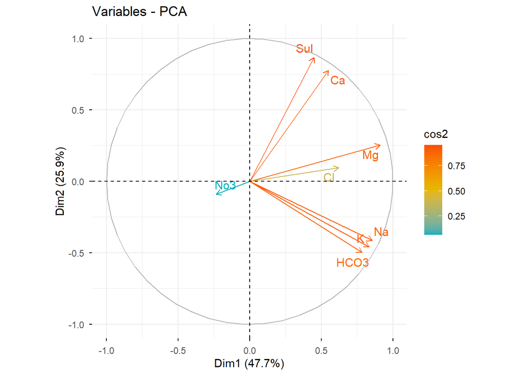

```r
fviz_pca_var(res.pca, col.var = "cos2",
             gradient.cols = c("#00AFBB", "#E7B800", "#FC4E07"),
             repel = TRUE)
```

**Interpretation:** Variables coloured red/orange are well represented (high cos²). **Mg, Na, K, HCO3** point to the right (PC1+ = high mineralisation). **Ca and Sul** point upward (PC2+ = gypsum waters). **No3** appears as a very short arrow near the origin — poorly represented in this plane (cos² ≈ 0.06).

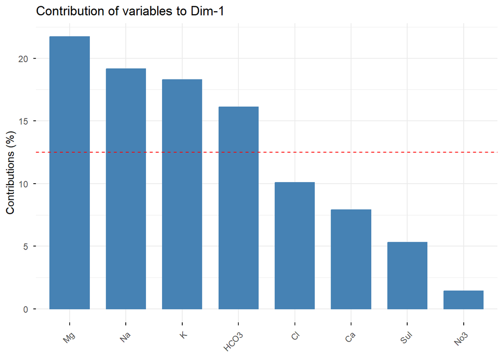

```r
# Contributions of variables to the first component
fviz_contrib(res.pca, choice = "var", axes = 1, top = 8)
```

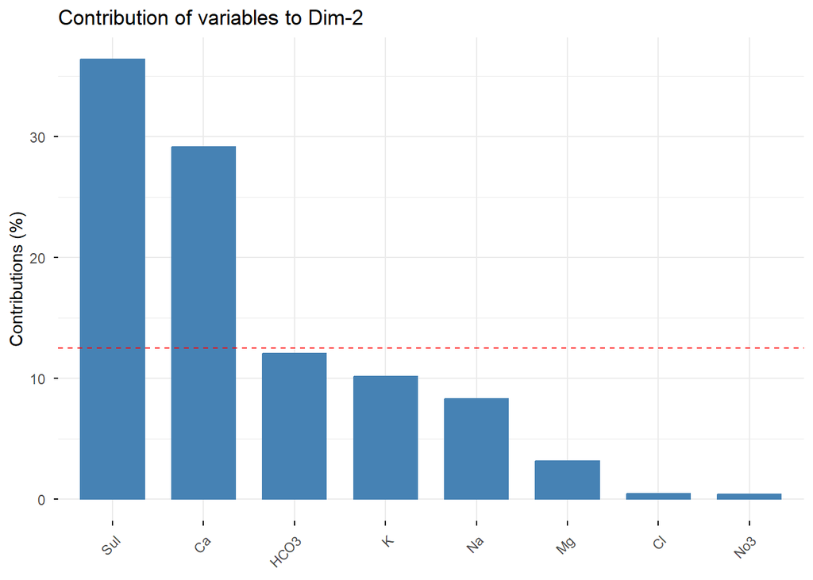

```r
# Contributions of variables to the second component
fviz_contrib(res.pca, choice = "var", axes = 2, top = 8)
```

**Interpretation:** The bar charts confirm the variable contributions to each axis. The dashed red line represents the expected contribution if all variables contributed equally (100/8 = 12.5%). The red dashed line = threshold 12.5%. PC1: Mg, Na, K, HCO3 are the dominant contributors. PC2: Sul and Ca dominate, confirming the sulphated-calcic vs. sodic-bicarbonate opposition.

## Contributions

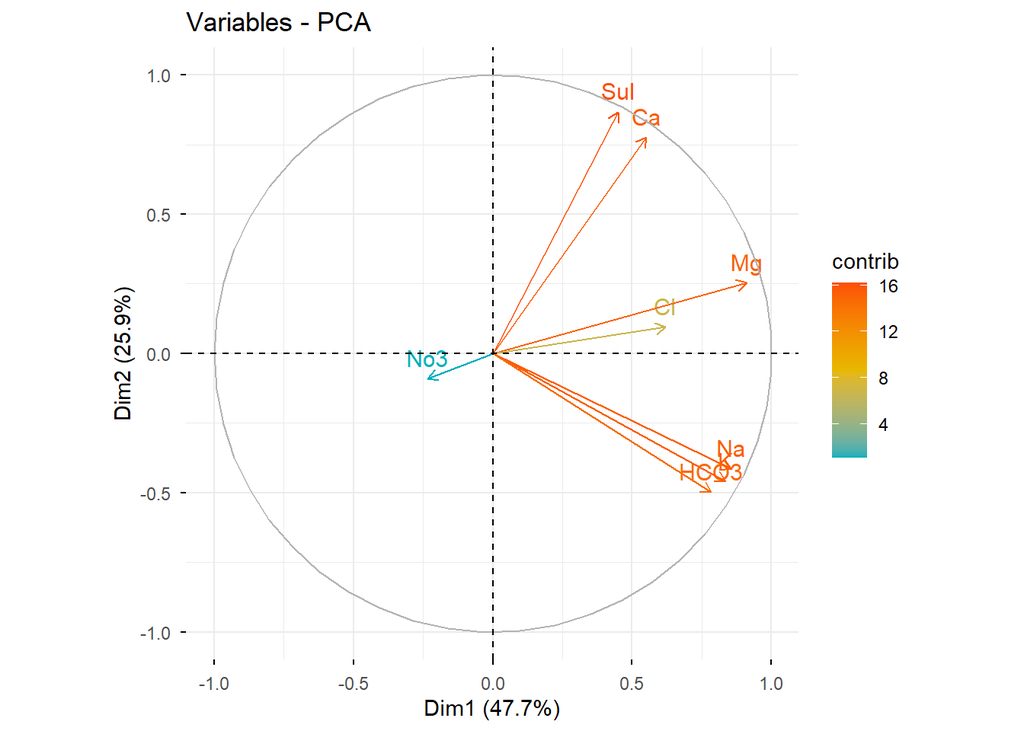

```r
# Highlight the most important variables
fviz_pca_var(res.pca, col.var = "contrib",
             gradient.cols = c("#00AFBB", "#E7B800", "#FC4E07"))
```

**Interpretation:** This correlation circle colours variables by their total contribution across both axes (PC1 + PC2). Variables in red/orange are the most influential in structuring the factorial plane. Mg, Na, K, Sul, HCO3 appear in warm colours, confirming they are the key drivers of the ACP_eaux dataset structure. No3 and Cl appear in cool colours, indicating lower overall contribution to the first two dimensions.

## The Individuals

```r
res.desc <- dimdesc(res.pca, axes = c(1, 2), proba = 0.05)
res.desc$Dim.2
```

```
##
## Link between the variable and the continuous variables (R-square)
## =================================================================================
##      correlation      p.value
## Sul    0.8675799 2.528799e-18
## Ca     0.7764150 1.279229e-12
## Na    -0.4142770 1.356729e-03
## K     -0.4584741 3.350678e-04
## HCO3  -0.4988958 7.814521e-05
```

```r
ind <- get_pca_ind(res.pca)
ind
```

```
## Principal Component Analysis Results for individuals
##  ===================================================
##   Name       Description
## 1 "$coord"   "Coordinates for the individuals"
## 2 "$cos2"    "Cos2 for the individuals"
## 3 "$contrib" "contributions of the individuals"
```

## Individuals (Dimension 1)

```r
res.desc$Dim.1
```

```
##
## Link between the variable and the continuous variables (R-square)
## =================================================================================
##      correlation      p.value
## Mg     0.9104573 9.573425e-23
## Na     0.8551621 2.510398e-17
## K      0.8354674 6.376416e-16
## HCO3   0.7840386 5.492255e-13
## Cl     0.6203998 2.640912e-07
## Ca     0.5496004 9.518680e-06
## Sul    0.4496677 4.495443e-04
```

**Interpretation of Dim.1:** For **Dimension 1**, all ionic variables except No3 are positively and significantly associated with PC1. This confirms that PC1 represents a global mineralisation gradient. Waters scoring high on PC1 (e.g., Parot, Arvie, La Française, Quézac) are among the most highly mineralised waters in the dataset. Waters scoring very low on PC1 (e.g., Mont Roucous, Volcania, Montcalm) are extremely low in minerals, typical of spring waters from granite geological formations with very low ion content.

## Individuals: Coordinates

```r
head(ind$coord)
```

```
##            Dim.1       Dim.2      Dim.3        Dim.4       Dim.5
## EVIAN -0.7178823 -0.06437824 -0.0632024 -0.207095048 -0.17745653
## MTPYR -0.9533595 -0.19481163 -0.1497913  0.326838545  0.01220447
## CRIST -0.9784818 -0.16488904 -0.5405736  0.003437127  0.06841751
## FIEE  -0.3815899  0.11246248 -0.6020300 -0.208141232 -0.22247130
## VOLCA -1.4505989 -0.33499878 -0.7130627  0.151704103  0.06848312
## STDIE  3.5431484 -1.47681895 -0.1272594  0.556811591 -0.95183533
```

**Interpretation:** The coordinates of individuals on the factorial plane show how far each water deviates from the average profile (origin). A water at the origin has an average ionic composition across all variables. Extreme positions indicate atypical chemical profiles.  
Key examples: **PARO** (PC1 = +6.55, HCO3 = 3381 mg/L), **ARVIE** (PC1 = +6.46, volcanic spring), **CONTR** (PC2 = +4.26, Ca+Sul dominant), **MTROU** (PC1 = −1.51, ultra-low mineralisation).

## Quality of representation

```r
head(ind$cos2)
```

```
##           Dim.1       Dim.2       Dim.3        Dim.4       Dim.5
## EVIAN 0.7266271 0.005843639 0.005632125 6.047064e-02 0.044400625
## MTPYR 0.8431923 0.035208130 0.020815466 9.910139e-02 0.000138182
## CRIST 0.6938608 0.019703818 0.211775866 8.561659e-06 0.003392356
## FIEE  0.1819551 0.015804679 0.452904510 5.413606e-02 0.061846965
## VOLCA 0.7488159 0.039936205 0.180940492 8.189832e-03 0.001668966
## STDIE 0.7812788 0.135731883 0.001007876 1.929496e-02 0.056383366
```

```r
round(ind$cos2, 2)
```

```
##        Dim.1 Dim.2 Dim.3 Dim.4 Dim.5
## EVIAN   0.73  0.01  0.01  0.06  0.04
## MTPYR   0.84  0.04  0.02  0.10  0.00
## CRIST   0.69  0.02  0.21  0.00  0.00
## FIEE    0.18  0.02  0.45  0.05  0.06
## VOLCA   0.75  0.04  0.18  0.01  0.00
## STDIE   0.78  0.14  0.00  0.02  0.06
## LUCHO   0.83  0.03  0.12  0.01  0.00
## VOLV    0.82  0.08  0.01  0.03  0.01
## ALMO    0.87  0.00  0.12  0.00  0.00
## ORBOI   0.23  0.64  0.00  0.04  0.02
## ARVIE   0.81  0.14  0.00  0.00  0.03
## ALROC   0.87  0.00  0.12  0.00  0.00
## ONDI    0.67  0.03  0.28  0.00  0.00
## THON    0.39  0.00  0.58  0.00  0.00
## ALBNS   0.44  0.00  0.35  0.09  0.02
## CONTR   0.19  0.72  0.01  0.08  0.00
## BSHI    0.27  0.01  0.69  0.03  0.00
## DAX     0.22  0.23  0.21  0.21  0.00
## QUEZ    0.75  0.01  0.00  0.16  0.04
## SALV    0.00  0.06  0.01  0.20  0.02
## STAM    0.66  0.01  0.32  0.00  0.00
## IOLH    0.53  0.01  0.06  0.00  0.12
## AVRA    0.09  0.00  0.89  0.01  0.00
## ROUV    0.88  0.03  0.06  0.01  0.00
## ALIS    0.85  0.04  0.08  0.01  0.00
## SBEN    0.61  0.03  0.08  0.01  0.08
## SPEL    0.13  0.77  0.03  0.01  0.01
## LEVI    0.80  0.03  0.14  0.01  0.00
## VERA    0.93  0.02  0.03  0.00  0.00
## STANT   0.94  0.04  0.01  0.01  0.00
## LAFR    0.47  0.12  0.00  0.41  0.00
## STBEN   0.67  0.03  0.28  0.00  0.00
## PLANC   0.42  0.03  0.49  0.01  0.01
## STALI   0.58  0.06  0.29  0.04  0.00
## PSTGC   0.27  0.42  0.10  0.01  0.17
## STGCO   0.66  0.04  0.26  0.03  0.00
## HILDB   0.17  0.01  0.79  0.02  0.00
## HILDW   0.84  0.00  0.02  0.00  0.01
## MTROU   0.82  0.04  0.09  0.02  0.00
## OGEU    0.87  0.03  0.02  0.08  0.00
## HISP    0.77  0.02  0.21  0.00  0.00
## PARO    0.69  0.25  0.00  0.04  0.02
## VERN    0.67  0.01  0.00  0.21  0.10
## TERF    0.55  0.00  0.16  0.02  0.02
## COUR    0.12  0.79  0.01  0.06  0.01
## PYR     0.90  0.03  0.02  0.05  0.00
## PSGM    0.27  0.41  0.10  0.01  0.16
## PRINN   0.17  0.75  0.00  0.07  0.00
## MTCA    0.76  0.03  0.17  0.01  0.00
## CHANT   0.17  0.05  0.33  0.20  0.02
## CAR18   0.06  0.09  0.45  0.10  0.13
## SPWA    0.12  0.00  0.86  0.01  0.01
## VALS    0.33  0.46  0.01  0.03  0.18
## VERNET  0.04  0.68  0.10  0.06  0.02
## SIHAR   0.08  0.01  0.01  0.64  0.10
## SIAL    0.62  0.04  0.30  0.01  0.00
## MTCLA   0.91  0.03  0.05  0.00  0.00
```

**Interpretation:** The cos² values for individuals indicate how well each water is represented in the PC1×PC2 plane. A cos² close to 1 on a given component means the water’s profile is almost entirely captured by that axis. For instance:

- Waters with very extreme positions (Parot, Arvie, Contrex, Courmayeur, Prince Noir) tend to have high cos² values on PC1 or PC2, meaning their chemical profile is well summarised by those two dimensions.
- Waters with more balanced ionic compositions (close to the average) may be less well represented in 2D but contribute less to the interpretation.

## Contributions

```r
head(ind$contrib)
```

```
##            Dim.1       Dim.2       Dim.3        Dim.4       Dim.5
## EVIAN 0.23688366 0.003515879 0.007203801 9.449732e-02 0.308292073
## MTPYR 0.41777461 0.032194773 0.040463871 2.353676e-01 0.001458198
## CRIST 0.44008256 0.023064242 0.526992168 2.602982e-05 0.045826106
## FIEE  0.06693025 0.010729288 0.653628155 9.545448e-02 0.484536363
## VOLCA 0.96721565 0.095201123 0.916959048 5.070779e-02 0.045914039
## STDIE 5.77041823 1.850163585 0.029206158 6.831194e-01 8.869559027
```

**Interpretation:** Individual contributions (in %) indicate which waters most strongly determine the orientation and scale of each principal component. Waters with the highest contributions to PC1 are those with the most extreme mineralisation: Parot (PARO), Arvie (ARVIE), and La Française (LAFR). For PC2, the main contributors are Contrex (CONTR), Courmayeur (COUR), and Prince Noir (PRINN) on the positive side, and Parot and Arvie on the negative side. These waters are therefore the most “structuring” observations in the dataset, they drive the geometry of the factorial plane.

## Contributions on first two components

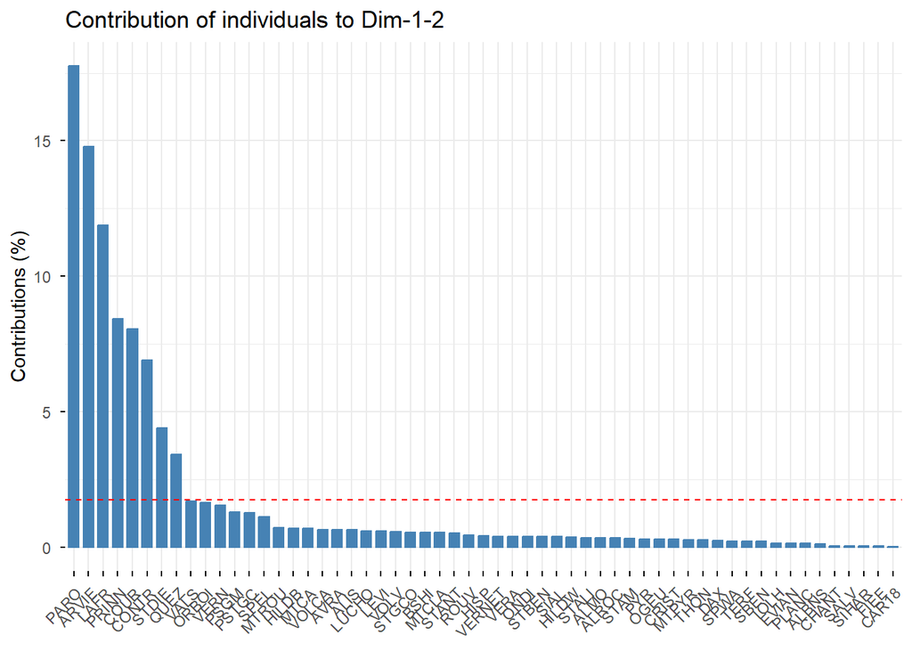

```r
fviz_contrib(res.pca, choice = "ind", axes = 1:2)
```

**Interpretation:** This bar chart shows the total contribution of each water to the first two principal components combined. The dashed red line represents the average expected contribution (100/57 ≈ 1.75%). Waters exceeding this threshold are the most influential in shaping the factorial plane. Notably, **Parot, Arvie, La Française, Contrex, Courmayeur, and Prince Noir** stand out as the most structuring observations. Their atypical chemical compositions drive the principal axes and must be interpreted with particular attention, as they may also influence the clustering results.

## Individuals plot

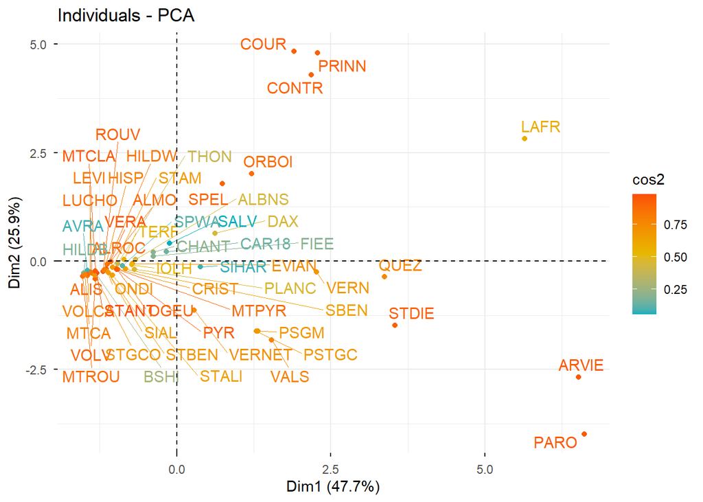

```r
fviz_pca_ind(res.pca, col.ind = "cos2",
             gradient.cols = c("#00AFBB", "#E7B800", "#FC4E07"),
             repel = TRUE)
```

**Interpretation:** The individual factor map displays all 57 mineral waters in the PC1×PC2 plane, coloured by their quality of representation (cos²). Key observations:

- **Right side (high PC1):** Highly mineralised waters:Parot, Arvie, La Française, Quézac, Vernière, all gaseous volcanic springs or deep thermal waters.
- **Upper right (high PC1 + PC2):** Sulphated-calcic waters:Contrex, Courmayeur, Prince Noir, characterised by very high Ca and Sul from gypsum dissolution.
- **Left side (low PC1):** Very low mineralisation waters: Mont Roucous, Volcania, Montcalm, Levissima, typical of granite spring waters.
- **Centre:** Most standard mineral waters cluster near the origin (moderate and balanced mineralisation).
- Waters with warm colours (red/orange) are well represented in this 2D plane; those in blue are less well captured and may be better described by PC3 or PC4.

## Clustering – Hierarchical Clustering (CAH)

```r
# Use scores on PC1:PC4 (95.7% of cumulative variance)
scores4 <- ind$coord[, 1:4]

# Euclidean distance matrix
d <- dist(scores4, method = "euclidean")

# Ward.D2 linkage
hc <- hclust(d, method = "ward.D2")
```

**Interpretation:** The hierarchical clustering is performed on the principal component scores (PC1 to PC4) rather than the raw data. This approach has two advantages: (1) it removes the effect of variable scale differences, as the PCA already standardised the data; (2) it reduces noise by discarding the last components (PC5–PC8) which represent only 4.3% of total variance. The **Ward.D2** linkage criterion minimises the total within-cluster variance at each merging step, producing compact and well-separated clusters.

## Dendrogram

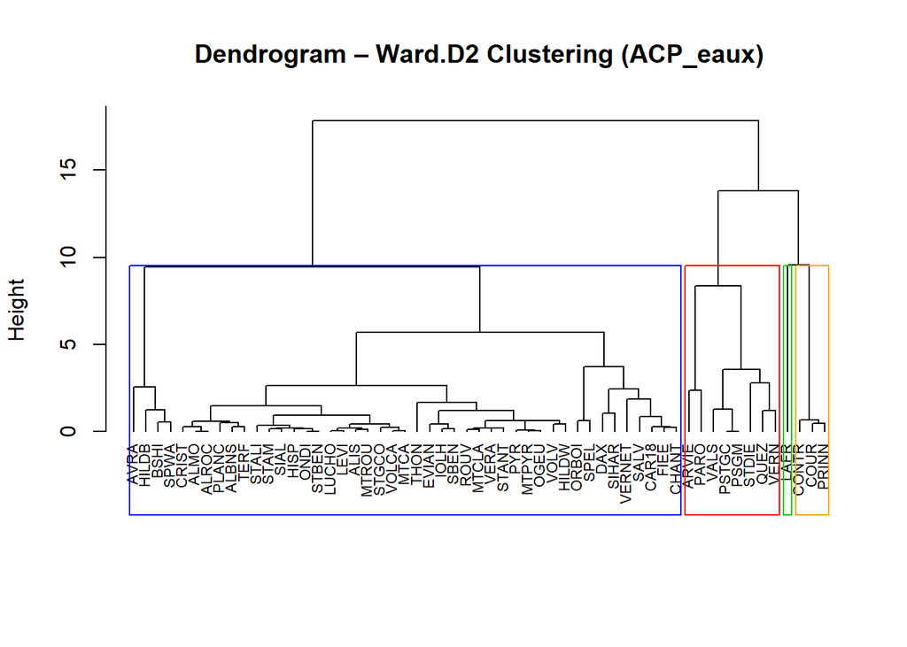

```r
plot(hc,
     main = "Dendrogram – Ward.D2 Clustering (ACP_eaux)",
     xlab = "", sub = "", hang = -1, cex = 0.7)
rect.hclust(hc, k = 4, border = c("blue", "red", "green3", "orange"))
```

## Cluster membership (k = 4)

```r
ct <- cutree(hc, k = 4)
print(ct)
```

```
##  EVIAN  MTPYR  CRIST   FIEE  VOLCA  STDIE  LUCHO   VOLV   ALMO  ORBOI  ARVIE
##      1      1      1      1      1      2      1      1      1      1      2
##  ALROC   ONDI   THON  ALBNS  CONTR   BSHI    DAX   QUEZ   SALV   STAM   IOLH
##      1      1      1      1      3      1      1      2      1      1      1
##   AVRA   ROUV   ALIS   SBEN   SPEL   LEVI   VERA  STANT   LAFR  STBEN  PLANC
##      1      1      1      1      1      1      1      1      4      1      1
##  STALI  PSTGC  STGCO  HILDB  HILDW  MTROU   OGEU   HISP   PARO   VERN   TERF
##      1      2      1      1      1      1      1      1      2      2      1
##   COUR    PYR   PSGM  PRINN   MTCA  CHANT  CAR18   SPWA   VALS VERNET  SIHAR
##      3      1      2      3      1      1      1      1      2      1      1
##   SIAL  MTCLA
##      1      1
```

```r
table(ct)
```

```
## ct
##  1  2  3  4
## 45  8  3  1
```

**Interpretation:** Cutting the dendrogram at k = 4 produces the following partition:

- **Cluster 1 (45 waters, 79%):** The large majority group, standard mineral waters with moderate mineralisation.
- **Cluster 2 (8 waters, 14%):** Highly mineralised sodic-bicarbonate waters of volcanic or deep thermal origin.
- **Cluster 3 (3 waters, 5%):** Exceptionally sulphated-calcic waters from gypsum-rich geological formations.
- **Cluster 4 (1 water, 2%):** La Française, a singleton with a unique chloride-sodium profile (Na = 653 mg/L, Cl = 982 mg/L simultaneously), unlike any other water in the dataset.

## Cluster means (original variables)

```r
for (i in 1:4) {
  cat("\n--- Cluster", i, "---\n")
  print(round(colMeans(X[ct == i, ]), 2))
}
```

```
##
## --- Cluster 1 ---
##     Ca     Mg     Na      K    Sul    No3   HCO3     Cl
##  67.40  14.37  21.08   3.01  52.08   4.29 225.52  23.76
##
## --- Cluster 2 ---
##      Ca      Mg      Na       K     Sul     No3    HCO3      Cl
##  115.28   64.42  466.12   58.31   54.24    2.61 1741.24  115.15
##
## --- Cluster 3 ---
##      Ca      Mg      Na       K     Sul     No3    HCO3      Cl
##  510.33   76.33    6.37    2.73 1300.00    1.57  300.00    6.20
##
## --- Cluster 4 ---
##   Ca   Mg   Na    K  Sul  No3 HCO3   Cl
##  354   83  653   22 1055    0  225  982
```

**Interpretation:** Each cluster has a distinct geochemical identity: **Cluster 1**:moderate mineralisation, standard table waters (Evian, Volvic). **Cluster 2** :very high Na, K, HCO3; volcanic gaseous springs (Parot, Arvie, Quézac). **Cluster 3**:extreme Ca and Sul; gypsum waters (Contrex, Courmayeur, Prince Noir). **Cluster 4**:La Française alone; unique NaCl-dominant brine profile.

## Individuals coloured by cluster

```
## Too few points to calculate an ellipse
## Too few points to calculate an ellipse
```

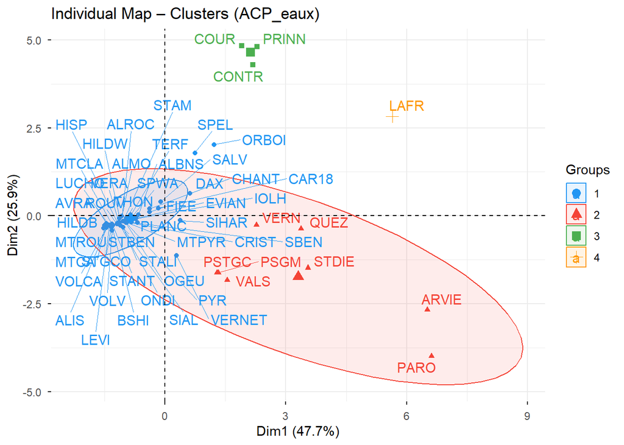

```r
fviz_pca_ind(res.pca,
             habillage = as.factor(ct),
             addEllipses = TRUE,
             ellipse.level = 0.90,
             palette = c("#2196F3", "#F44336", "#4CAF50", "#FF9800"),
             repel = TRUE,
             title = "Individual Map – Clusters (ACP_eaux)")
```

**Interpretation:** The four clusters are spatially coherent in the factorial plane: **Cluster 1 (blue)** is compact around the origin. The 90% confidence ellipse is compact and well-centred. **Cluster 2 (red)** Waters spread along the negative PC2 / positive PC1 direction, high mineralisation with sodic-bicarbonate dominance. The ellipse extends horizontally towards the right. **Cluster 3 (green)** occupies the upper-right quadrant (PC1+, PC2+). **Cluster 4(orange)**, La Française stands alone, isolated from all other groups, confirming its unique chloride-sodium profile that cannot be classified within any of the other three geochemical families. —

## Biplot (variables + individuals coloured by cluster)

```
## Too few points to calculate an ellipse
## Too few points to calculate an ellipse
```

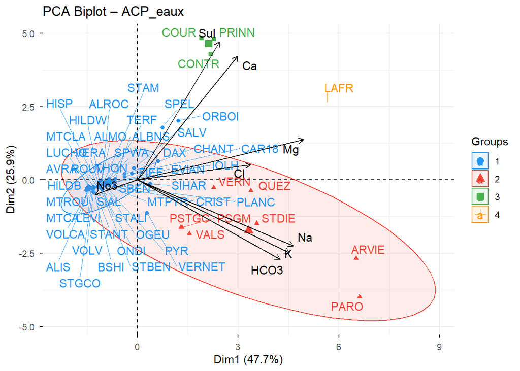

```r
fviz_pca_biplot(res.pca,
                habillage = as.factor(ct),
                addEllipses = TRUE,
                ellipse.level = 0.90,
                palette = c("#2196F3", "#F44336", "#4CAF50", "#FF9800"),
                col.var = "black",
                repel = TRUE,
                title = "PCA Biplot – ACP_eaux")
```